# Compare pairwise dN/dS for clades affected by GC jumps

### Background

Previously, for a subset of datasets, I have tried estimating dN, dS using a non-stationary codon model. However, we now uspect that this model does not fit the data well leading to biased estimates of dN,dS on long branches. Therefore, I will now attempt an alternate approach. I will try to test for changes in other genomic proxies which can give indication of evolutionary forces acting on the genomes. These include- 1. dN/dS (inceased dN/dS indicates increased drift) 2. CUB (decreased CUb indicates decreased Ne.s) 3. rate of 16s rRNA evolution (increased rate indicates increased drift/mutation) 4. genome size (reductions can be due to increased drift or increased streamlining selection) 5. coding density (decrease indicates drift, increase indicates streamlinign selection) 6. length of intergenic region (decrease indicates increased streamlining selection)

estimate pairwise dN/dS within taxa of the focal clades (affected by jumps) and compare it with dN/dS of pairs in the corresponding sister or related clades.

#### Common data and input processing

```r
library(parallel)

library(phytools)
library(rncl)
library(seqinr)

library(tidyverse)
library(reshape2)

library(cowplot)
library(viridis)
library(ggpubr)
library(patchwork)
library(dendextend)

n_cores_av <- 3

main_dir <- "../"
input_dir <- "../Input_data/"
levolution_data_dir <- "../Input_data/levolution_files_inference_actual_data/"
jump_common_dir <- "../Results/jump_analysis/"

GTDB_14k_tree <- read_newick_phylo(file = paste0(main_dir, "Input_data/phylogenies/GTDB_bac120_r80_pruned0.01.newick"))
GTDB_14k_metadata <- read.delim(file = paste0(main_dir, "Input_data/phylogenies/GTDB_bac_metadata_r80_pruned0.01.tsv"), header = T, row.names = 1, stringsAsFactors = F)

levolution_best_fit_parameters <- read.table(file = paste0(levolution_data_dir, "levolution_best_fit_parameters_summary.txt"), row.names = 1, header = T, stringsAsFactors = F)

gd_base <- paste0(main_dir, "Input_data/GTDB_data/GTDB_")
fn_types <- c("ass_fn", "ft_fn", "cds_fn", "rna_fn", "ftcnt_fn", "fna_fn", "gb_fn", "prot_fn")
gdirs_oi <- c("assembly_reports/", "feature_tables/", "cds/", "rna/", "feature_counts/", "genomes/", "gb/", "proteins/")
names(gdirs_oi) <- fn_types

download_script <- paste0(main_dir, "Codes/download_all_genome_files_from_GCFonly.py")
source(file = paste0(main_dir, "Codes/plotTree.wBars.R"))

OLclades_oi <- c("Sphingomonadale", "Rhizobiale", "Rhodobacterale", "Alpha1", "Bacteroidale", "Cytophagale", "Flavobacteriale","Pseudomonadale", "Enterobacterales", "Betaproteo")
p_folders <- c(rep("Alphaproteo",4), rep("Bacteroidetes",3), rep("Gammaproteo", 3))
pp_cutoffs <- c(0.75,0.75,0.75,0.95,0.95,0.95,0.75, 0.9,0.9,0.9)
alphas_oi <- c(1,1,1,0.5,0.25,0.25,1,0.25,0.5,0.5)
config_oi <- 1

get_genera_sp_names <- function(full_GTDB_taxonomy){
  GTDB_fields <- strsplit(x = full_GTDB_taxonomy, split = ";g__")[[1]]
  return(paste0("g__", GTDB_fields[2]))
}

clade_size_cutoff <- 20

cbPalette <- c("#999999", "#E69F00", "#56B4E9", "#009E73", "#F0E442", "#0072B2", "#D55E00", "#CC79A7")
##colorBlind_friendly_palette= black, orange, sky blue, bluish green, yellow, blue, vermillion, reddish purple
```

### Filtering datasets according to available clades and number of taxa

I will first find which focal jumps have appropriate sister groups and outgroup clades for further analysis. Clades should have at least a sister group.

I will also ignore focal jumps where sister or outgroup clades have more than 20 taxa, in order to make the downstream analysis more reliable and simpler. A large number of taxa in sister or outgroup clade increases the chances of heterogeneity in these groups used for comparison. These are treated separately.

```r
for(OLclade_n in 1:length(OLclades_oi)){
  OLclade_oi <- OLclades_oi[OLclade_n]
  print(paste0("Analysing jumps within ", OLclade_oi))
  pp_cutoff <- pp_cutoffs[OLclade_n]
  alpha_oi <- alphas_oi[OLclade_n]
  p_folder <- p_folders[OLclade_n]
  res_dir <- out_dir <-  levolution_data_dir

  tree_pp <- read.newick(file = paste0(res_dir,OLclade_oi,"_GTDB_14k_GC_config", config_oi, "_alpha", alpha_oi,".post"))
  tree_in <- read.newick(paste0(phylogenies_dir,OLclade_oi,"_GTDB_14k_tree.newick"))
  OLclade_nTips <- length(tree_in$tip.label) ##OL=OrderLevel

  OLclade_jumpBranches <- which(tree_pp$edge.length>pp_cutoff)

  jumpClade_details_colNames <- c("jumpBranch", "depth", "nTaxa_focal", "nTaxa_sis", "nTaxa_out1", "nTaxa_out2")
  jumpClade_details <- data.frame(matrix(NA, nrow = length(OLclade_jumpBranches), ncol = length(jumpClade_details_colNames), dimnames = list(paste0("jump", 1:length(OLclade_jumpBranches)), jumpClade_details_colNames)))
  # jumpClade_details <- read.table(file = paste0(jump_common_dir, OLclade_oi, "_jumpSummaries.tab"), stringsAsFactors = F)

  for(jumpNum_oi in 1:length(OLclade_jumpBranches)){
    too_large <- F
    print(jumpNum_oi)
    jumpDir <- paste0(jump_common_dir, OLclade_oi, "_jump", jumpNum_oi, "/")
    system2(command = "mkdir", args = c(jumpDir), stdout = F, stderr = F)

    jumpBranch_oi <- OLclade_jumpBranches[jumpNum_oi]

    anc_node <- tree_in$edge[jumpBranch_oi,1] #parent node of jump branch
    focal_root <- tree_in$edge[jumpBranch_oi,2] #descendant node of jump branch
    focal_descendants <- getDescendants(tree=tree_in, node=focal_root)
    focal_tips <- intersect(1:OLclade_nTips, focal_descendants)
    focal_tip_labels <- tree_in$tip.label[focal_tips]
    write.table(focal_tip_labels, file = paste0(jumpDir, OLclade_oi, "_jump", jumpNum_oi, "_focalGTDBLabels.tab"), row.names = F, col.names = F)
    nTaxa_focal <- length(focal_tips)

    ##check if there are any other, nested jumps in this focal clade
    all_nestedFocalTips <- c()
    nested_jumpBranches <- setdiff(intersect(OLclade_jumpBranches, which(tree_in$edge[,2] %in% focal_descendants)), jumpBranch_oi)
    nested_focalNodes <- sapply(nested_jumpBranches, function(x) getDescendants(tree_in, tree_in$edge[x,2]))
    nested_focalTips <- intersect(unlist(nested_focalNodes), 1:length(tree_in$tip.label))
    all_nestedFocalTips <- nested_focalTips

    sis_root <- setdiff(tree_in$edge[which(tree_in$edge[,1]==anc_node), 2], focal_root) #the other descendant of ancestral node
    sis_branch <- intersect(which(tree_in$edge[,1]==anc_node),which(tree_in$edge[,2]==sis_root))
    sis_descendants <- getDescendants(tree = tree_in, node = sis_root)
    sis_tips <- intersect(1:length(tree_in$tip.label), sis_descendants)
    sis_tip_labels <- tree_in$tip.label[sis_tips]
    write.table(sis_tip_labels, file = paste0(jumpDir, OLclade_oi, "_jump", jumpNum_oi, "_sisGTDBLabels.tab"), row.names = F, col.names = F)
    nTaxa_sis <- length(sis_tips)

    ##check if there are any additional, nested jumps in the sister clade
    nested_jumpBranches <- intersect(OLclade_jumpBranches, which(tree_in$edge[,2] %in% c(sis_root, sis_descendants)))
    nested_focalNodes <- sapply(nested_jumpBranches, function(x) getDescendants(tree_in, tree_in$edge[x,2]))
    nested_focalTips <- intersect(unlist(nested_focalNodes), 1:length(tree_in$tip.label))
    all_nestedFocalTips <- c(all_nestedFocalTips, nested_focalTips)

    anc_out1 <- tree_in$edge[which(tree_in$edge[,2]==anc_node),1] #parent of ancestral node

    if(identical(anc_out1, numeric(0))){ #if ancestor of outgroup cant be found, most likely because focal clade diverges from the root, so there is no outgroup
      print("cant find outgroup! Is focal clade at the root?")
      if(all(c(nTaxa_focal, nTaxa_sis) <= clade_size_cutoff)){
        jumpClade_details[paste0("jump", jumpNum_oi), ] <- c(jumpBranch_oi, "sister", nTaxa_focal, nTaxa_sis, NA, NA)
      }else{
        jumpClade_details[paste0("jump", jumpNum_oi), ] <- c(jumpBranch_oi, "focal", nTaxa_focal, nTaxa_sis, NA, NA)
      }
      write.table(tree_in$tip.label[all_nestedFocalTips], file = paste0(jumpDir, "nestedFocalTips.tab"), quote = F, row.names = F, col.names = F)

      next #skip this jump for remaining analysis
    }

    out1_root <- setdiff(tree_in$edge[which(tree_in$edge[,1]==anc_out1),2],anc_node)
    out1_branch <- intersect(which(tree_in$edge[,1]==anc_out1),which(tree_in$edge[,2]==out1_root))
    out1_descendants <- getDescendants(tree=tree_in, node=out1_root)
    out1_tips <- intersect(1:length(tree_in$tip.label), out1_descendants)
    out1_tip_labels <- tree_in$tip.label[out1_tips]
    write.table(out1_tip_labels, file = paste0(jumpDir, OLclade_oi, "_jump", jumpNum_oi, "_out1GTDBLabels.tab"), row.names = F, col.names = F)
    nTaxa_out1 <- length(out1_tips)

    ##check if there are any additional, nested jumps in the outgroup clades
    nested_jumpBranches <- intersect(OLclade_jumpBranches, which(tree_in$edge[,2] %in% c(out1_root, out1_descendants)))
    nested_focalNodes <- sapply(nested_jumpBranches, function(x) getDescendants(tree_in, tree_in$edge[x,2]))
    nested_focalTips <- intersect(unlist(nested_focalNodes), 1:length(tree_in$tip.label))
    all_nestedFocalTips <- c(all_nestedFocalTips, nested_focalTips)

    anc_out2 <- tree_in$edge[which(tree_in$edge[,2]==anc_out1),1] #parent of ancestor of first outgroup
    if(identical(anc_out2, numeric(0))){ #if ancestor of 2nd outgroup cant be found, most likely because 1st outgroup diverges from root, so there is no other outgroup
      print("cant find 2nd outgroup! Is 1st outgroup at the root?")

      ##if focal, sister and outgroup1 have limited taxa
      if(all(c(nTaxa_focal, nTaxa_sis, nTaxa_out1)  <=  clade_size_cutoff)){
        #extract focal_clade
        focal_clade_tree <- extract.clade(tree_in, anc_out1)
        jumpClade_details[paste0("jump", jumpNum_oi), ] <- c(jumpBranch_oi, "outgroup1", nTaxa_focal, nTaxa_sis, nTaxa_out1, NA)
        write.table(tree_in$tip.label[all_nestedFocalTips], file = paste0(jumpDir, "nestedFocalTips.tab"), quote = F, row.names = F, col.names = F)
      }else if(all(c(nTaxa_focal, nTaxa_sis) <= clade_size_cutoff)){
        # focal_clade_tree <- extract.clade(tree_in, anc_node)
        # jumpClade_details[paste0("jump", jumpNum_oi), ] <- c(jumpBranch_oi, "sister", nTaxa_focal, nTaxa_sis, nTaxa_out1, NA)
        # write.table(tree_in$tip.label[all_nestedFocalTips], file = paste0(jumpDir, "nestedFocalTips.tab"), quote = F, row.names = F, col.names = F)
        print("Either focal, sister, or outgroup clade is too large. Will not analyze this jump directly.")
        jumpClade_details[paste0("jump", jumpNum_oi), ] <- c(jumpBranch_oi, "outgroup1", nTaxa_focal, nTaxa_sis, nTaxa_out1, NA)
        write.table(tree_in$tip.label[all_nestedFocalTips], file = paste0(jumpDir, "nestedFocalTips.tab"), quote = F, row.names = F, col.names = F)
        too_large <- T
      }else{
        print("Either focal, sister, or outgroup clade is too large. Will not analyze this jump directly.")
        jumpClade_details[paste0("jump", jumpNum_oi), ] <- c(jumpBranch_oi, "outgroup1", nTaxa_focal, nTaxa_sis, nTaxa_out1, NA)
        write.table(tree_in$tip.label[all_nestedFocalTips], file = paste0(jumpDir, "nestedFocalTips.tab"), quote = F, row.names = F, col.names = F)
        too_large <- T
      } ##end of if, focal, sister, and outgroup1 have limited taxa
```

```r
      if(exists("too_large")) next ##skip this jump if focal or sister clades are too large #these are dealt with separately

      #if focal, sister, and first outgroup are small, identify edges for coloring
      if(nTaxa_focal == 1){
        focal_edges <- which(focal_clade_tree$edge[,2]==which(focal_clade_tree$tip.label==focal_tip_labels))
      }else if(nTaxa_focal > 1){
        clade_tree_focal_root <- getMRCA(focal_clade_tree, focal_tip_labels)
        focal_edges <- which(focal_clade_tree$edge[,2] %in% c(clade_tree_focal_root, getDescendants(focal_clade_tree, clade_tree_focal_root)))
      }

      if(nTaxa_sis == 1){
        sis_edges <- which(focal_clade_tree$edge[,2]==which(focal_clade_tree$tip.label==sis_tip_labels))
      }else if(nTaxa_sis > 1){
        clade_tree_sis_root <- getMRCA(focal_clade_tree, sis_tip_labels)
        sis_edges <- which(focal_clade_tree$edge[,2] %in% c(clade_tree_sis_root, getDescendants(focal_clade_tree, clade_tree_sis_root)))
      }

      edge_colors <- rep("black", length(focal_clade_tree$edge.length))
      edge_colors[focal_edges] <- "orange"
      edge_colors[sis_edges] <- "purple"

      #change labels to species names for plotting
      focal_clade_tree_labeled <- focal_clade_tree
      focal_clade_tree_labeled$tip.label <- sapply(focal_clade_tree$tip.label, function(x) get_genera_sp_names(GTDB_14k_metadata[x,"gtdb_taxonomy"]), simplify = T, USE.NAMES = F)

      #plot tree for reference
      svg(filename = paste0(jumpDir, OLclade_oi, "_jump", jumpNum_oi, "_cladeTree.svg"), width = max(max(nodeHeights(focal_clade_tree))*50,5), height = max(length(focal_clade_tree$tip.label)*0.5, 3))
      plot(focal_clade_tree, edge.color = edge_colors, edge.width = 2)
      add.scale.bar()
      dev.off()

      svg(filename = paste0(jumpDir, OLclade_oi, "_jump", jumpNum_oi, "_cladeTree_labeled.svg"), width = max(max(nodeHeights(focal_clade_tree_labeled))*50,5), height = max(length(focal_clade_tree_labeled$tip.label)*0.5, 5))
      plot(focal_clade_tree_labeled, edge.color = edge_colors, edge.width = 2)
      add.scale.bar()
      dev.off()

      write.tree(focal_clade_tree, file = paste0(jumpDir, OLclade_oi, "_jump", jumpNum_oi, ".newick"))
      write.tree(focal_clade_tree_labeled, file = paste0(jumpDir, OLclade_oi, "_jump", jumpNum_oi, "_labeled.newick"))

      next #skip this jump now
    }##end of if, outgroup 2 not found

    ##if outgroup2 is found, we continue
    out2_root <- setdiff(tree_in$edge[which(tree_in$edge[,1]==anc_out2),2],anc_out1)
    out2_branch <- intersect(which(tree_in$edge[,1]==anc_out2),which(tree_in$edge[,2]==out2_root))
    out2_descendants <- getDescendants(tree=tree_in, node=out2_root)
    out2_tips <- intersect(1:length(tree_in$tip.label), out2_descendants)
    out2_tip_labels <- tree_in$tip.label[out2_tips]
    write.table(out2_tip_labels, file = paste0(jumpDir, OLclade_oi, "_jump", jumpNum_oi, "_out2GTDBLabels.tab"), row.names = F, col.names = F)
    nTaxa_out2 <- length(out2_tips)

    ##check if there are any additional, nested jumps in the outgroup2 clades
    nested_jumpBranches <- intersect(OLclade_jumpBranches, which(tree_in$edge[,2] %in% c(out2_root, out2_descendants)))
    nested_focalNodes <- sapply(nested_jumpBranches, function(x) getDescendants(tree_in, tree_in$edge[x,2]))
    nested_focalTips <- intersect(unlist(nested_focalNodes), 1:length(tree_in$tip.label))
    all_nestedFocalTips <- c(all_nestedFocalTips, nested_focalTips)
    write.table(tree_in$tip.label[all_nestedFocalTips], file = paste0(jumpDir, "nestedFocalTips.tab"), quote = F, row.names = F, col.names = F)

    if(all(c(nTaxa_focal, nTaxa_sis, nTaxa_out1, nTaxa_out2) <=  clade_size_cutoff)){
      focal_clade_tree <- extract.clade(tree_in, anc_out2)
      jumpClade_details[paste0("jump", jumpNum_oi), ] <- c(jumpBranch_oi, "outgroup2", nTaxa_focal, nTaxa_sis, nTaxa_out1, nTaxa_out2)
    }else if(all(c(nTaxa_focal, nTaxa_sis, nTaxa_out1) <=  clade_size_cutoff)){
      focal_clade_tree <- extract.clade(tree_in, anc_out1)
      jumpClade_details[paste0("jump", jumpNum_oi), ] <- c(jumpBranch_oi, "outgroup1", nTaxa_focal, nTaxa_sis, nTaxa_out1, nTaxa_out2)
    }else if(all(c(nTaxa_focal, nTaxa_sis)  <=  clade_size_cutoff)){
      print("Either focal, sister, or outgroup clade is too large. Will not analyze this jump directly.")
      jumpClade_details[paste0("jump", jumpNum_oi), ] <- c(jumpBranch_oi, "outgroup1", nTaxa_focal, nTaxa_sis, nTaxa_out1, NA)
      write.table(tree_in$tip.label[all_nestedFocalTips], file = paste0(jumpDir, "nestedFocalTips.tab"), quote = F, row.names = F, col.names = F)
      too_large <- T
    }else{
      print("Either focal, sister, or outgroup clade is too large. Will not analyze this jump directly.")
      jumpClade_details[paste0("jump", jumpNum_oi), ] <- c(jumpBranch_oi, "outgroup1", nTaxa_focal, nTaxa_sis, nTaxa_out1, NA)
      write.table(tree_in$tip.label[all_nestedFocalTips], file = paste0(jumpDir, "nestedFocalTips.tab"), quote = F, row.names = F, col.names = F)
      too_large <- T
    }

    if(too_large==T){
      next ##skip this jump if focal or sister clades are too large #these are dealt with separately
    }

    ##idenitfy edges for coloring
    if(nTaxa_focal == 1){
      focal_edges <- which(focal_clade_tree$edge[,2]==which(focal_clade_tree$tip.label==focal_tip_labels))
    }else if(nTaxa_focal > 1){
      clade_tree_focal_root <- getMRCA(focal_clade_tree, focal_tip_labels)
      focal_edges <- which(focal_clade_tree$edge[,2] %in% c(clade_tree_focal_root, getDescendants(focal_clade_tree, clade_tree_focal_root)))
    }

    if(nTaxa_sis == 1){
      sis_edges <- which(focal_clade_tree$edge[,2]==which(focal_clade_tree$tip.label==sis_tip_labels))
    }else if(nTaxa_sis > 1){
      clade_tree_sis_root <- getMRCA(focal_clade_tree, sis_tip_labels)
      sis_edges <- which(focal_clade_tree$edge[,2] %in% c(clade_tree_sis_root, getDescendants(focal_clade_tree, clade_tree_sis_root)))
    }

    edge_colors <- rep("black", length(focal_clade_tree$edge.length))
    edge_colors[focal_edges] <- "orange"
    edge_colors[sis_edges] <- "purple"
```

```r
    #change labels to species names for plotting
    focal_clade_tree_labeled <- focal_clade_tree
    focal_clade_tree_labeled$tip.label <- sapply(focal_clade_tree$tip.label, function(x) get_genera_sp_names(GTDB_14k_metadata[x,"gtdb_taxonomy"]), simplify = T, USE.NAMES = F)

    #plot tree for reference
    svg(filename = paste0(jumpDir, OLclade_oi, "_jump", jumpNum_oi, "_cladeTree.svg"), width = max(max(nodeHeights(focal_clade_tree))*50,5), height = max(length(focal_clade_tree$tip.label)*0.5, 3))
    plot(focal_clade_tree, edge.color = edge_colors, edge.width = 2)
    add.scale.bar()
    dev.off()

    svg(filename = paste0(jumpDir, OLclade_oi, "_jump", jumpNum_oi, "_cladeTree_labeled.svg"), width = max(max(nodeHeights(focal_clade_tree_labeled))*50,5), height = max(length(focal_clade_tree_labeled$tip.label)*0.5, 5))
    plot(focal_clade_tree_labeled, edge.color = edge_colors, edge.width = 2)
    add.scale.bar()
    dev.off()

    write.tree(focal_clade_tree, file = paste0(jumpDir, OLclade_oi, "_jump", jumpNum_oi, ".newick"))
    write.tree(focal_clade_tree_labeled, file = paste0(jumpDir, OLclade_oi, "_jump", jumpNum_oi, "_labeled.newick"))
  }#finish looping over jumps within a order-level clade
  write.table(jumpClade_details, file = paste0(jump_common_dir, OLclade_oi, "_jumpSummaries.tab"), quote = F)
}#finish looping over order-level clades
```

```
[1] "Analysing jumps within Sphingomonadale"
```

```
Read 1 item
Read 1 item
```

```
[1] 1
[1] "cant find 2nd outgroup! Is 1st outgroup at the root?"
[1] "Either focal, sister, or outgroup clade is too large. Will not analyze this jump directly."
[1] 2
[1] "Either focal, sister, or outgroup clade is too large. Will not analyze this jump directly."
[1] 3
[1] 4
[1] 5
[1] 6
[1] 7
[1] 8
[1] 9
[1] 10
[1] 11
[1] "Analysing jumps within Rhizobiale"
```

```
Read 1 item
Read 1 item
```

```
[1] 1
[1] 2
[1] 3
[1] 4
[1] "Either focal, sister, or outgroup clade is too large. Will not analyze this jump directly."
[1] 5
[1] "Either focal, sister, or outgroup clade is too large. Will not analyze this jump directly."
[1] 6
[1] "Either focal, sister, or outgroup clade is too large. Will not analyze this jump directly."
[1] 7
[1] 8
[1] 9
[1] "Either focal, sister, or outgroup clade is too large. Will not analyze this jump directly."
[1] 10
[1] "Either focal, sister, or outgroup clade is too large. Will not analyze this jump directly."
```

[output cut: 19 more lines]

```
Read 1 item
Read 1 item
```

```
[1] 1
[1] 2
[1] "Either focal, sister, or outgroup clade is too large. Will not analyze this jump directly."
[1] 3
[1] 4
[1] "Either focal, sister, or outgroup clade is too large. Will not analyze this jump directly."
[1] 5
[1] 6
[1] 7
[1] "cant find 2nd outgroup! Is 1st outgroup at the root?"
[1] "Either focal, sister, or outgroup clade is too large. Will not analyze this jump directly."
[1] 8
[1] "Either focal, sister, or outgroup clade is too large. Will not analyze this jump directly."
[1] 9
[1] 10
```

[output cut: 21 more lines]

```
Read 1 item
Read 1 item
```

```
[1] 1
[1] 2
[1] 3
[1] 4
[1] 5
[1] 6
[1] 7
[1] "Either focal, sister, or outgroup clade is too large. Will not analyze this jump directly."
[1] "Analysing jumps within Bacteroidale"
```

```
Read 1 item
Read 1 item
```

```
[1] 1
[1] 2
[1] 3
[1] "Analysing jumps within Cytophagale"
```

```
Read 1 item
Read 1 item
```

```
[1] 1
[1] 2
[1] "Either focal, sister, or outgroup clade is too large. Will not analyze this jump directly."
[1] "Analysing jumps within Flavobacteriale"
```

```
Read 1 item
Read 1 item
```

```
[1] 1
[1] "cant find 2nd outgroup! Is 1st outgroup at the root?"
[1] "Either focal, sister, or outgroup clade is too large. Will not analyze this jump directly."
[1] 2
[1] 3
[1] 4
[1] 5
[1] 6
[1] "Either focal, sister, or outgroup clade is too large. Will not analyze this jump directly."
[1] 7
[1] "Either focal, sister, or outgroup clade is too large. Will not analyze this jump directly."
[1] 8
[1] 9
[1] "Either focal, sister, or outgroup clade is too large. Will not analyze this jump directly."
[1] 10
```

[output cut: 81 more lines]

```
Read 1 item
Read 1 item
```

```
[1] 1
[1] 2
[1] 3
[1] 4
[1] 5
[1] "Either focal, sister, or outgroup clade is too large. Will not analyze this jump directly."
[1] 6
[1] 7
[1] 8
[1] 9
[1] "Either focal, sister, or outgroup clade is too large. Will not analyze this jump directly."
[1] 10
[1] "Either focal, sister, or outgroup clade is too large. Will not analyze this jump directly."
[1] 11
[1] 12
[1] 13
[1] "Analysing jumps within Enterobacterales"
```

```
Read 1 item
Read 1 item
```

```
[1] 1
[1] 2
[1] 3
[1] 4
[1] "Either focal, sister, or outgroup clade is too large. Will not analyze this jump directly."
[1] 5
[1] "Either focal, sister, or outgroup clade is too large. Will not analyze this jump directly."
[1] 6
[1] 7
[1] 8
[1] 9
[1] 10
[1] 11
[1] 12
[1] 13
[1] 14
[1] 15
[1] "Either focal, sister, or outgroup clade is too large. Will not analyze this jump directly."
[1] 16
[1] "Either focal, sister, or outgroup clade is too large. Will not analyze this jump directly."
[1] 17
[1] 18
[1] "Analysing jumps within Betaproteo"
```

```
Read 1 item
Read 1 item
```

```
[1] 1
[1] 2
[1] 3
[1] "Either focal, sister, or outgroup clade is too large. Will not analyze this jump directly."
[1] 4
[1] "Either focal, sister, or outgroup clade is too large. Will not analyze this jump directly."
[1] 5
[1] 6
[1] "Either focal, sister, or outgroup clade is too large. Will not analyze this jump directly."
[1] 7
[1] "Either focal, sister, or outgroup clade is too large. Will not analyze this jump directly."
[1] 8
[1] "Either focal, sister, or outgroup clade is too large. Will not analyze this jump directly."
[1] 9
[1] 10
```

[output cut: 22 more lines]

### Genome properties analysis

Here, I will analyze the changes in GC content and genome size, coding density, and protein branch lengths.

#### Extract genome properties

```r
for(OLclade_n in 1:length(OLclades_oi)){
  OLclade_oi <- OLclades_oi[OLclade_n]
  print(paste0("Analysing jumps within ", OLclade_oi))
  pp_cutoff <- pp_cutoffs[OLclade_n]
  alpha_oi <- alphas_oi[OLclade_n]
  p_folder <- p_folders[OLclade_n]
  res_dir <- out_dir <-  levolution_data_dir

  tree_pp <- read.newick(file = paste0(res_dir, OLclade_oi,"_GTDB_14k_GC_config", config_oi, "_alpha", alpha_oi,".post"))
  tree_in <- read.newick(paste0(phylogenies_dir,OLclade_oi,"_GTDB_14k_tree.newick"))
  OLclade_nTips <- length(tree_in$tip.label) ##OL=OrderLevel
  OLclade_jumpBranches <- which(tree_pp$edge.length>pp_cutoff)

  jumpClade_details <- read.table(file = paste0(jump_common_dir, OLclade_oi, "_jumpSummaries.tab"), stringsAsFactors = F)

  colNames_genome_details <- c("focal_GC", "sis_GC")
  genome_details <- as.data.frame(matrix(data = NA, nrow = nrow(jumpClade_details), ncol = length(colNames_genome_details), dimnames = list(paste0(OLclade_oi, "_jump", 1:nrow(jumpClade_details)), colNames_genome_details)))

  for(jumpNum_oi in which(jumpClade_details$depth %in% c("sister", "outgroup1", "outgroup2"))){#only for those jumps which are analyzable
    print(paste0("Extracting genome information for jump number ", jumpNum_oi))

    jumpDir <- paste0(jump_common_dir, OLclade_oi, "_jump", jumpNum_oi, "/")

    nested_focalTip_labels <- tryCatch({
      read.table(file = paste0(jumpDir, "nestedFocalTips.tab"), stringsAsFactors = F)$V1
    }, error=function(e){
      print(e)
      return(NA)
    })

    focal_GTDBLabels <- read.table(paste0(jumpDir, OLclade_oi,"_jump",jumpNum_oi,"_focalGTDBLabels.tab"), stringsAsFactors = F, header = F)
    focal_GTDBLabels_valid <- setdiff(focal_GTDBLabels$V1, nested_focalTip_labels)

    sis_GTDBLabels <- read.table(paste0(jumpDir,OLclade_oi,"_jump",jumpNum_oi,"_sisGTDBLabels.tab"), stringsAsFactors = F, header = F)
    sis_GTDBLabels_valid <- setdiff(sis_GTDBLabels$V1, nested_focalTip_labels)

    if(jumpClade_details[paste0("jump",jumpNum_oi), "depth"] %in% c("outgroup1", "outgroup2")){
      out1_GTDBLabels <- read.table(paste0(jumpDir,OLclade_oi,"_jump",jumpNum_oi,"_out1GTDBLabels.tab"), stringsAsFactors = F, header = F)
      out1_GTDBLabels_valid <- setdiff(out1_GTDBLabels$V1, nested_focalTip_labels)
    }

    if(jumpClade_details[paste0("jump",jumpNum_oi), "depth"]=="outgroup2"){
      out2_GTDBLabels <- read.table(paste0(jumpDir,OLclade_oi,"_jump",jumpNum_oi,"_out2GTDBLabels.tab"), stringsAsFactors = F, header = F)
      out2_GTDBLabels_valid <- setdiff(out2_GTDBLabels$V1, nested_focalTip_labels)
    }

    focal_GC <- median(GTDB_14k_metadata[focal_GTDBLabels_valid,"gc_percentage"])
    sis_GC <- median(GTDB_14k_metadata[sis_GTDBLabels_valid,"gc_percentage"])
    genome_details[paste0(OLclade_oi, "_jump", jumpNum_oi),] <- c(focal_GC, sis_GC)
  }##end of loop over jumps in a clade
  write.table(genome_details, file = paste0(jump_common_dir, OLclade_oi, "_genome_details.tab"), quote = F)
} ##end of loop over order level clades
```

```
[1] "Analysing jumps within Sphingomonadale"
```

```
Read 1 item
Read 1 item
```

```
[1] "Extracting genome information for jump number 1"
[1] "Extracting genome information for jump number 2"
[1] "Extracting genome information for jump number 3"
[1] "Extracting genome information for jump number 4"
<simpleError in read.table(file = paste0(jumpDir, "nestedFocalTips.tab"), stringsAsFactors = F): no lines available in input>
[1] "Extracting genome information for jump number 5"
<simpleError in read.table(file = paste0(jumpDir, "nestedFocalTips.tab"), stringsAsFactors = F): no lines available in input>
[1] "Extracting genome information for jump number 6"
[1] "Extracting genome information for jump number 7"
[1] "Extracting genome information for jump number 8"
[1] "Extracting genome information for jump number 9"
[1] "Extracting genome information for jump number 10"
[1] "Extracting genome information for jump number 11"
[1] "Analysing jumps within Rhizobiale"
```

```
Read 1 item
Read 1 item
```

```
[1] "Extracting genome information for jump number 1"
[1] "Extracting genome information for jump number 2"
[1] "Extracting genome information for jump number 3"
[1] "Extracting genome information for jump number 4"
<simpleError in read.table(file = paste0(jumpDir, "nestedFocalTips.tab"), stringsAsFactors = F): no lines available in input>
[1] "Extracting genome information for jump number 5"
[1] "Extracting genome information for jump number 6"
[1] "Extracting genome information for jump number 7"
[1] "Extracting genome information for jump number 8"
<simpleError in read.table(file = paste0(jumpDir, "nestedFocalTips.tab"), stringsAsFactors = F): no lines available in input>
[1] "Extracting genome information for jump number 9"
[1] "Extracting genome information for jump number 10"
[1] "Extracting genome information for jump number 11"
[1] "Extracting genome information for jump number 12"
<simpleError in read.table(file = paste0(jumpDir, "nestedFocalTips.tab"), stringsAsFactors = F): no lines available in input>
```

[output cut: 19 more lines]

```
Read 1 item
Read 1 item
```

```
[1] "Extracting genome information for jump number 1"
<simpleError in read.table(file = paste0(jumpDir, "nestedFocalTips.tab"), stringsAsFactors = F): no lines available in input>
[1] "Extracting genome information for jump number 2"
[1] "Extracting genome information for jump number 3"
<simpleError in read.table(file = paste0(jumpDir, "nestedFocalTips.tab"), stringsAsFactors = F): no lines available in input>
[1] "Extracting genome information for jump number 4"
[1] "Extracting genome information for jump number 5"
<simpleError in read.table(file = paste0(jumpDir, "nestedFocalTips.tab"), stringsAsFactors = F): no lines available in input>
[1] "Extracting genome information for jump number 6"
<simpleError in read.table(file = paste0(jumpDir, "nestedFocalTips.tab"), stringsAsFactors = F): no lines available in input>
[1] "Extracting genome information for jump number 7"
[1] "Extracting genome information for jump number 8"
[1] "Extracting genome information for jump number 9"
<simpleError in read.table(file = paste0(jumpDir, "nestedFocalTips.tab"), stringsAsFactors = F): no lines available in input>
[1] "Extracting genome information for jump number 10"
<simpleError in read.table(file = paste0(jumpDir, "nestedFocalTips.tab"), stringsAsFactors = F): no lines available in input>
[1] "Extracting genome information for jump number 11"
<simpleError in read.table(file = paste0(jumpDir, "nestedFocalTips.tab"), stringsAsFactors = F): no lines available in input>
[1] "Extracting genome information for jump number 12"
<simpleError in read.table(file = paste0(jumpDir, "nestedFocalTips.tab"), stringsAsFactors = F): no lines available in input>
[1] "Extracting genome information for jump number 13"
<simpleError in read.table(file = paste0(jumpDir, "nestedFocalTips.tab"), stringsAsFactors = F): no lines available in input>
[1] "Extracting genome information for jump number 14"
[1] "Extracting genome information for jump number 15"
<simpleError in read.table(file = paste0(jumpDir, "nestedFocalTips.tab"), stringsAsFactors = F): no lines available in input>
[1] "Extracting genome information for jump number 16"
[1] "Extracting genome information for jump number 17"
[1] "Extracting genome information for jump number 18"
[1] "Extracting genome information for jump number 19"
[1] "Extracting genome information for jump number 20"
<simpleError in read.table(file = paste0(jumpDir, "nestedFocalTips.tab"), stringsAsFactors = F): no lines available in input>
[1] "Extracting genome information for jump number 21"
<simpleError in read.table(file = paste0(jumpDir, "nestedFocalTips.tab"), stringsAsFactors = F): no lines available in input>
[1] "Extracting genome information for jump number 22"
<simpleError in read.table(file = paste0(jumpDir, "nestedFocalTips.tab"), stringsAsFactors = F): no lines available in input>
[1] "Extracting genome information for jump number 23"
<simpleError in read.table(file = paste0(jumpDir, "nestedFocalTips.tab"), stringsAsFactors = F): no lines available in input>
[1] "Extracting genome information for jump number 24"
[1] "Extracting genome information for jump number 25"
[1] "Extracting genome information for jump number 26"
<simpleError in read.table(file = paste0(jumpDir, "nestedFocalTips.tab"), stringsAsFactors = F): no lines available in input>
[1] "Extracting genome information for jump number 27"
<simpleError in read.table(file = paste0(jumpDir, "nestedFocalTips.tab"), stringsAsFactors = F): no lines available in input>
[1] "Analysing jumps within Alpha1"
```

```
Read 1 item
Read 1 item
```

```
[1] "Extracting genome information for jump number 1"
<simpleError in read.table(file = paste0(jumpDir, "nestedFocalTips.tab"), stringsAsFactors = F): no lines available in input>
[1] "Extracting genome information for jump number 2"
[1] "Extracting genome information for jump number 3"
<simpleError in read.table(file = paste0(jumpDir, "nestedFocalTips.tab"), stringsAsFactors = F): no lines available in input>
[1] "Extracting genome information for jump number 4"
<simpleError in read.table(file = paste0(jumpDir, "nestedFocalTips.tab"), stringsAsFactors = F): no lines available in input>
[1] "Extracting genome information for jump number 5"
[1] "Extracting genome information for jump number 6"
[1] "Extracting genome information for jump number 7"
<simpleError in read.table(file = paste0(jumpDir, "nestedFocalTips.tab"), stringsAsFactors = F): no lines available in input>
[1] "Analysing jumps within Bacteroidale"
```

```
Read 1 item
Read 1 item
```

```
[1] "Extracting genome information for jump number 1"
<simpleError in read.table(file = paste0(jumpDir, "nestedFocalTips.tab"), stringsAsFactors = F): no lines available in input>
[1] "Extracting genome information for jump number 2"
<simpleError in read.table(file = paste0(jumpDir, "nestedFocalTips.tab"), stringsAsFactors = F): no lines available in input>
[1] "Extracting genome information for jump number 3"
<simpleError in read.table(file = paste0(jumpDir, "nestedFocalTips.tab"), stringsAsFactors = F): no lines available in input>
[1] "Analysing jumps within Cytophagale"
```

```
Read 1 item
Read 1 item
```

```
[1] "Extracting genome information for jump number 1"
<simpleError in read.table(file = paste0(jumpDir, "nestedFocalTips.tab"), stringsAsFactors = F): no lines available in input>
[1] "Extracting genome information for jump number 2"
<simpleError in read.table(file = paste0(jumpDir, "nestedFocalTips.tab"), stringsAsFactors = F): no lines available in input>
[1] "Analysing jumps within Flavobacteriale"
```

```
Read 1 item
Read 1 item
```

```
[1] "Extracting genome information for jump number 1"
[1] "Extracting genome information for jump number 2"
[1] "Extracting genome information for jump number 3"
[1] "Extracting genome information for jump number 4"
<simpleError in read.table(file = paste0(jumpDir, "nestedFocalTips.tab"), stringsAsFactors = F): no lines available in input>
[1] "Extracting genome information for jump number 5"
[1] "Extracting genome information for jump number 6"
[1] "Extracting genome information for jump number 7"
[1] "Extracting genome information for jump number 8"
[1] "Extracting genome information for jump number 9"
[1] "Extracting genome information for jump number 10"
[1] "Extracting genome information for jump number 11"
<simpleError in read.table(file = paste0(jumpDir, "nestedFocalTips.tab"), stringsAsFactors = F): no lines available in input>
[1] "Extracting genome information for jump number 12"
[1] "Extracting genome information for jump number 13"
```

[output cut: 77 more lines]

```
Read 1 item
Read 1 item
```

```
[1] "Extracting genome information for jump number 1"
[1] "Extracting genome information for jump number 2"
[1] "Extracting genome information for jump number 3"
<simpleError in read.table(file = paste0(jumpDir, "nestedFocalTips.tab"), stringsAsFactors = F): no lines available in input>
[1] "Extracting genome information for jump number 4"
<simpleError in read.table(file = paste0(jumpDir, "nestedFocalTips.tab"), stringsAsFactors = F): no lines available in input>
[1] "Extracting genome information for jump number 5"
[1] "Extracting genome information for jump number 6"
[1] "Extracting genome information for jump number 7"
<simpleError in read.table(file = paste0(jumpDir, "nestedFocalTips.tab"), stringsAsFactors = F): no lines available in input>
[1] "Extracting genome information for jump number 8"
<simpleError in read.table(file = paste0(jumpDir, "nestedFocalTips.tab"), stringsAsFactors = F): no lines available in input>
[1] "Extracting genome information for jump number 9"
[1] "Extracting genome information for jump number 10"
[1] "Extracting genome information for jump number 11"
<simpleError in read.table(file = paste0(jumpDir, "nestedFocalTips.tab"), stringsAsFactors = F): no lines available in input>
[1] "Extracting genome information for jump number 12"
<simpleError in read.table(file = paste0(jumpDir, "nestedFocalTips.tab"), stringsAsFactors = F): no lines available in input>
[1] "Extracting genome information for jump number 13"
<simpleError in read.table(file = paste0(jumpDir, "nestedFocalTips.tab"), stringsAsFactors = F): no lines available in input>
[1] "Analysing jumps within Enterobacterales"
```

```
Read 1 item
Read 1 item
```

```
[1] "Extracting genome information for jump number 1"
[1] "Extracting genome information for jump number 2"
<simpleError in read.table(file = paste0(jumpDir, "nestedFocalTips.tab"), stringsAsFactors = F): no lines available in input>
[1] "Extracting genome information for jump number 3"
[1] "Extracting genome information for jump number 4"
[1] "Extracting genome information for jump number 5"
[1] "Extracting genome information for jump number 6"
<simpleError in read.table(file = paste0(jumpDir, "nestedFocalTips.tab"), stringsAsFactors = F): no lines available in input>
[1] "Extracting genome information for jump number 7"
<simpleError in read.table(file = paste0(jumpDir, "nestedFocalTips.tab"), stringsAsFactors = F): no lines available in input>
[1] "Extracting genome information for jump number 8"
<simpleError in read.table(file = paste0(jumpDir, "nestedFocalTips.tab"), stringsAsFactors = F): no lines available in input>
[1] "Extracting genome information for jump number 9"
<simpleError in read.table(file = paste0(jumpDir, "nestedFocalTips.tab"), stringsAsFactors = F): no lines available in input>
[1] "Extracting genome information for jump number 10"
[1] "Extracting genome information for jump number 11"
[1] "Extracting genome information for jump number 12"
[1] "Extracting genome information for jump number 13"
[1] "Extracting genome information for jump number 14"
<simpleError in read.table(file = paste0(jumpDir, "nestedFocalTips.tab"), stringsAsFactors = F): no lines available in input>
[1] "Extracting genome information for jump number 15"
[1] "Extracting genome information for jump number 16"
[1] "Extracting genome information for jump number 17"
<simpleError in read.table(file = paste0(jumpDir, "nestedFocalTips.tab"), stringsAsFactors = F): no lines available in input>
[1] "Extracting genome information for jump number 18"
<simpleError in read.table(file = paste0(jumpDir, "nestedFocalTips.tab"), stringsAsFactors = F): no lines available in input>
[1] "Analysing jumps within Betaproteo"
```

```
Read 1 item
Read 1 item
```

```
[1] "Extracting genome information for jump number 1"
[1] "Extracting genome information for jump number 2"
[1] "Extracting genome information for jump number 3"
[1] "Extracting genome information for jump number 4"
[1] "Extracting genome information for jump number 5"
<simpleError in read.table(file = paste0(jumpDir, "nestedFocalTips.tab"), stringsAsFactors = F): no lines available in input>
[1] "Extracting genome information for jump number 6"
[1] "Extracting genome information for jump number 7"
[1] "Extracting genome information for jump number 8"
<simpleError in read.table(file = paste0(jumpDir, "nestedFocalTips.tab"), stringsAsFactors = F): no lines available in input>
[1] "Extracting genome information for jump number 9"
[1] "Extracting genome information for jump number 10"
[1] "Extracting genome information for jump number 11"
<simpleError in read.table(file = paste0(jumpDir, "nestedFocalTips.tab"), stringsAsFactors = F): no lines available in input>
[1] "Extracting genome information for jump number 12"
[1] "Extracting genome information for jump number 13"
[1] "Extracting genome information for jump number 14"
[1] "Extracting genome information for jump number 15"
[1] "Extracting genome information for jump number 16"
[1] "Extracting genome information for jump number 17"
[1] "Extracting genome information for jump number 18"
[1] "Extracting genome information for jump number 19"
<simpleError in read.table(file = paste0(jumpDir, "nestedFocalTips.tab"), stringsAsFactors = F): no lines available in input>
[1] "Extracting genome information for jump number 20"
<simpleError in read.table(file = paste0(jumpDir, "nestedFocalTips.tab"), stringsAsFactors = F): no lines available in input>
[1] "Extracting genome information for jump number 21"
<simpleError in read.table(file = paste0(jumpDir, "nestedFocalTips.tab"), stringsAsFactors = F): no lines available in input>
[1] "Extracting genome information for jump number 22"
[1] "Extracting genome information for jump number 23"
```

#### Plotting of genome comparisons

```r
all_genome_comparisons <- do.call(rbind, lapply(OLclades_oi, function(x) read.table(paste0(jump_common_dir,x,"_genome_details.tab"), stringsAsFactors = F, header = T, row.names = 1)))
write.table(all_genome_comparisons, file = paste0(jump_common_dir, "levolution_jumps_genome_comparison.tab"), quote = F)
```

### Lifestyle properties analysis

Recently an integrated dataset of lifestyle properties has become available. It integrates data from various sources, but at the species level. Lets see if we can extract some features from it. I will first focus on habitat- soil vs aquatic, and metabolism- aerobic vs rest.

#### Extract lifestyle properties

```r
taxmap_gtdb <- read.csv(paste0(input_dir, "trait_data/taxmap_gtdb.csv"), stringsAsFactors=F, row.names = 1)
trait_data_gtdb <- read.csv(paste0(input_dir, "trait_data/condensed_species_GTDB.csv"), stringsAsFactors=F, row.names = 1)
trait_data_ncbi <- read.csv(paste0(input_dir, "trait_data/condensed_species_NCBI.csv"), stringsAsFactors=F, row.names = 1)

for(OLclade_n in 1:length(OLclades_oi)){
  OLclade_oi <- OLclades_oi[OLclade_n]
  print(paste0("Analysing jumps within ", OLclade_oi))
  pp_cutoff <- pp_cutoffs[OLclade_n]
  alpha_oi <- alphas_oi[OLclade_n]
  p_folder <- p_folders[OLclade_n]
  res_dir <- out_dir <-  levolution_data_dir

  tree_pp <- read.newick(file = paste0(res_dir,OLclade_oi,"_GTDB_14k_GC_config", config_oi, "_alpha", alpha_oi,".post"))
  tree_in <- read.newick(paste0(phylogenies_dir,OLclade_oi,"_GTDB_14k_tree.newick"))
  OLclade_nTips <- length(tree_in$tip.label) ##OL=OrderLevel
  OLclade_jumpBranches <- which(tree_pp$edge.length>pp_cutoff)

  jumpClade_details <- read.table(file = paste0(jump_common_dir, OLclade_oi, "_jumpSummaries.tab"), stringsAsFactors = F)

  colNames_lifestyle_details <- c("focal_habitat", "sis_habitat", "focal_metabolism", "sis_metabolism")
  lifestyle_details <- as.data.frame(matrix(data = NA, nrow = nrow(jumpClade_details), ncol = length(colNames_lifestyle_details), dimnames = list(paste0(OLclade_oi, "_jump", 1:nrow(jumpClade_details)), colNames_lifestyle_details)))

  for(jumpNum_oi in which(jumpClade_details$depth %in% c("sister", "outgroup1", "outgroup2"))){#only for those jumps which are analyzable
    print(paste0("Extracting genome information for jump number ", jumpNum_oi))

    jumpDir <- paste0(jump_common_dir, OLclade_oi, "_jump", jumpNum_oi, "/")

    nested_focalTip_labels <- tryCatch({
      read.table(file = paste0(jumpDir, "nestedFocalTips.tab"), stringsAsFactors = F)$V1
    }, error=function(e){
      print(e)
      return(NA)
    })

    focal_GTDBLabels <- read.table(paste0(jumpDir, OLclade_oi,"_jump",jumpNum_oi,"_focalGTDBLabels.tab"), stringsAsFactors = F, header = F)
    focal_GTDBLabels_valid <- setdiff(focal_GTDBLabels$V1, nested_focalTip_labels)

    sis_GTDBLabels <- read.table(paste0(jumpDir,OLclade_oi,"_jump",jumpNum_oi,"_sisGTDBLabels.tab"), stringsAsFactors = F, header = F)
    sis_GTDBLabels_valid <- setdiff(sis_GTDBLabels$V1, nested_focalTip_labels)

    out1_accNums <- NA
    if(jumpClade_details[paste0("jump",jumpNum_oi), "depth"] %in% c("outgroup1", "outgroup2")){
      out1_GTDBLabels <- read.table(paste0(jumpDir,OLclade_oi,"_jump",jumpNum_oi,"_out1GTDBLabels.tab"), stringsAsFactors = F, header = F)
      out1_GTDBLabels_valid <- setdiff(out1_GTDBLabels$V1, nested_focalTip_labels)
    }

    out2_accNums <- NA
    if(jumpClade_details[paste0("jump",jumpNum_oi), "depth"]=="outgroup2"){
      out2_GTDBLabels <- read.table(paste0(jumpDir,OLclade_oi,"_jump",jumpNum_oi,"_out2GTDBLabels.tab"), stringsAsFactors = F, header = F)
      out2_GTDBLabels_valid <- setdiff(out2_GTDBLabels$V1, nested_focalTip_labels)
    }

    focal_metabolisms <- paste0(sapply(sapply(focal_GTDBLabels_valid, function(x) taxmap_gtdb[x, "ncbi_species_taxid"]), function(y) trait_data_gtdb[as.character(y), "metabolism"]), collapse = "|")
    sis_metabolisms <- paste0(sapply(sapply(sis_GTDBLabels_valid, function(x) taxmap_gtdb[x, "ncbi_species_taxid"]), function(y) trait_data_gtdb[as.character(y), "metabolism"]),collapse = "|")
    focal_habitat <- paste0(sapply(sapply(focal_GTDBLabels_valid, function(x) taxmap_gtdb[x, "ncbi_species_taxid"]), function(y) strsplit(trait_data_gtdb[as.character(y), "isolation_source"], "_")[[1]][1]), collapse = "|")
    sis_habitat <- paste0(sapply(sapply(sis_GTDBLabels_valid, function(x) taxmap_gtdb[x, "ncbi_species_taxid"]), function(y) strsplit(trait_data_gtdb[as.character(y), "isolation_source"], "_")[[1]][1]),collapse = "|")

    lifestyle_details[paste0(OLclade_oi, "_jump", jumpNum_oi),] <- c(focal_habitat, sis_habitat, focal_metabolisms, sis_metabolisms)
  }##end of loop over jumps in a clade
  write.csv(lifestyle_details, file = paste0(jump_common_dir, OLclade_oi, "_lifestyle_details.csv"), quote = F)
} ##end of loop over order level clades
```

```
[1] "Analysing jumps within Sphingomonadale"
```

```
Read 1 item
Read 1 item
```

```
[1] "Extracting genome information for jump number 1"
[1] "Extracting genome information for jump number 2"
[1] "Extracting genome information for jump number 3"
[1] "Extracting genome information for jump number 4"
<simpleError in read.table(file = paste0(jumpDir, "nestedFocalTips.tab"), stringsAsFactors = F): no lines available in input>
[1] "Extracting genome information for jump number 5"
<simpleError in read.table(file = paste0(jumpDir, "nestedFocalTips.tab"), stringsAsFactors = F): no lines available in input>
[1] "Extracting genome information for jump number 6"
[1] "Extracting genome information for jump number 7"
[1] "Extracting genome information for jump number 8"
[1] "Extracting genome information for jump number 9"
[1] "Extracting genome information for jump number 10"
[1] "Extracting genome information for jump number 11"
[1] "Analysing jumps within Rhizobiale"
```

```
Read 1 item
Read 1 item
```

```
[1] "Extracting genome information for jump number 1"
[1] "Extracting genome information for jump number 2"
[1] "Extracting genome information for jump number 3"
[1] "Extracting genome information for jump number 4"
<simpleError in read.table(file = paste0(jumpDir, "nestedFocalTips.tab"), stringsAsFactors = F): no lines available in input>
[1] "Extracting genome information for jump number 5"
[1] "Extracting genome information for jump number 6"
[1] "Extracting genome information for jump number 7"
[1] "Extracting genome information for jump number 8"
<simpleError in read.table(file = paste0(jumpDir, "nestedFocalTips.tab"), stringsAsFactors = F): no lines available in input>
[1] "Extracting genome information for jump number 9"
[1] "Extracting genome information for jump number 10"
[1] "Extracting genome information for jump number 11"
[1] "Extracting genome information for jump number 12"
<simpleError in read.table(file = paste0(jumpDir, "nestedFocalTips.tab"), stringsAsFactors = F): no lines available in input>
```

[output cut: 19 more lines]

```
Read 1 item
Read 1 item
```

```
[1] "Extracting genome information for jump number 1"
<simpleError in read.table(file = paste0(jumpDir, "nestedFocalTips.tab"), stringsAsFactors = F): no lines available in input>
[1] "Extracting genome information for jump number 2"
[1] "Extracting genome information for jump number 3"
<simpleError in read.table(file = paste0(jumpDir, "nestedFocalTips.tab"), stringsAsFactors = F): no lines available in input>
[1] "Extracting genome information for jump number 4"
[1] "Extracting genome information for jump number 5"
<simpleError in read.table(file = paste0(jumpDir, "nestedFocalTips.tab"), stringsAsFactors = F): no lines available in input>
[1] "Extracting genome information for jump number 6"
<simpleError in read.table(file = paste0(jumpDir, "nestedFocalTips.tab"), stringsAsFactors = F): no lines available in input>
[1] "Extracting genome information for jump number 7"
[1] "Extracting genome information for jump number 8"
[1] "Extracting genome information for jump number 9"
<simpleError in read.table(file = paste0(jumpDir, "nestedFocalTips.tab"), stringsAsFactors = F): no lines available in input>
[1] "Extracting genome information for jump number 10"
<simpleError in read.table(file = paste0(jumpDir, "nestedFocalTips.tab"), stringsAsFactors = F): no lines available in input>
[1] "Extracting genome information for jump number 11"
<simpleError in read.table(file = paste0(jumpDir, "nestedFocalTips.tab"), stringsAsFactors = F): no lines available in input>
[1] "Extracting genome information for jump number 12"
<simpleError in read.table(file = paste0(jumpDir, "nestedFocalTips.tab"), stringsAsFactors = F): no lines available in input>
[1] "Extracting genome information for jump number 13"
<simpleError in read.table(file = paste0(jumpDir, "nestedFocalTips.tab"), stringsAsFactors = F): no lines available in input>
[1] "Extracting genome information for jump number 14"
[1] "Extracting genome information for jump number 15"
<simpleError in read.table(file = paste0(jumpDir, "nestedFocalTips.tab"), stringsAsFactors = F): no lines available in input>
[1] "Extracting genome information for jump number 16"
[1] "Extracting genome information for jump number 17"
[1] "Extracting genome information for jump number 18"
[1] "Extracting genome information for jump number 19"
[1] "Extracting genome information for jump number 20"
<simpleError in read.table(file = paste0(jumpDir, "nestedFocalTips.tab"), stringsAsFactors = F): no lines available in input>
[1] "Extracting genome information for jump number 21"
<simpleError in read.table(file = paste0(jumpDir, "nestedFocalTips.tab"), stringsAsFactors = F): no lines available in input>
[1] "Extracting genome information for jump number 22"
<simpleError in read.table(file = paste0(jumpDir, "nestedFocalTips.tab"), stringsAsFactors = F): no lines available in input>
[1] "Extracting genome information for jump number 23"
<simpleError in read.table(file = paste0(jumpDir, "nestedFocalTips.tab"), stringsAsFactors = F): no lines available in input>
[1] "Extracting genome information for jump number 24"
[1] "Extracting genome information for jump number 25"
[1] "Extracting genome information for jump number 26"
<simpleError in read.table(file = paste0(jumpDir, "nestedFocalTips.tab"), stringsAsFactors = F): no lines available in input>
[1] "Extracting genome information for jump number 27"
<simpleError in read.table(file = paste0(jumpDir, "nestedFocalTips.tab"), stringsAsFactors = F): no lines available in input>
[1] "Analysing jumps within Alpha1"
```

```
Read 1 item
Read 1 item
```

```
[1] "Extracting genome information for jump number 1"
<simpleError in read.table(file = paste0(jumpDir, "nestedFocalTips.tab"), stringsAsFactors = F): no lines available in input>
[1] "Extracting genome information for jump number 2"
[1] "Extracting genome information for jump number 3"
<simpleError in read.table(file = paste0(jumpDir, "nestedFocalTips.tab"), stringsAsFactors = F): no lines available in input>
[1] "Extracting genome information for jump number 4"
<simpleError in read.table(file = paste0(jumpDir, "nestedFocalTips.tab"), stringsAsFactors = F): no lines available in input>
[1] "Extracting genome information for jump number 5"
[1] "Extracting genome information for jump number 6"
[1] "Extracting genome information for jump number 7"
<simpleError in read.table(file = paste0(jumpDir, "nestedFocalTips.tab"), stringsAsFactors = F): no lines available in input>
[1] "Analysing jumps within Bacteroidale"
```

```
Read 1 item
Read 1 item
```

```
[1] "Extracting genome information for jump number 1"
<simpleError in read.table(file = paste0(jumpDir, "nestedFocalTips.tab"), stringsAsFactors = F): no lines available in input>
[1] "Extracting genome information for jump number 2"
<simpleError in read.table(file = paste0(jumpDir, "nestedFocalTips.tab"), stringsAsFactors = F): no lines available in input>
[1] "Extracting genome information for jump number 3"
<simpleError in read.table(file = paste0(jumpDir, "nestedFocalTips.tab"), stringsAsFactors = F): no lines available in input>
[1] "Analysing jumps within Cytophagale"
```

```
Read 1 item
Read 1 item
```

```
[1] "Extracting genome information for jump number 1"
<simpleError in read.table(file = paste0(jumpDir, "nestedFocalTips.tab"), stringsAsFactors = F): no lines available in input>
[1] "Extracting genome information for jump number 2"
<simpleError in read.table(file = paste0(jumpDir, "nestedFocalTips.tab"), stringsAsFactors = F): no lines available in input>
[1] "Analysing jumps within Flavobacteriale"
```

```
Read 1 item
Read 1 item
```

```
[1] "Extracting genome information for jump number 1"
[1] "Extracting genome information for jump number 2"
[1] "Extracting genome information for jump number 3"
[1] "Extracting genome information for jump number 4"
<simpleError in read.table(file = paste0(jumpDir, "nestedFocalTips.tab"), stringsAsFactors = F): no lines available in input>
[1] "Extracting genome information for jump number 5"
[1] "Extracting genome information for jump number 6"
[1] "Extracting genome information for jump number 7"
[1] "Extracting genome information for jump number 8"
[1] "Extracting genome information for jump number 9"
[1] "Extracting genome information for jump number 10"
[1] "Extracting genome information for jump number 11"
<simpleError in read.table(file = paste0(jumpDir, "nestedFocalTips.tab"), stringsAsFactors = F): no lines available in input>
[1] "Extracting genome information for jump number 12"
[1] "Extracting genome information for jump number 13"
```

[output cut: 77 more lines]

```
Read 1 item
Read 1 item
```

```
[1] "Extracting genome information for jump number 1"
[1] "Extracting genome information for jump number 2"
[1] "Extracting genome information for jump number 3"
<simpleError in read.table(file = paste0(jumpDir, "nestedFocalTips.tab"), stringsAsFactors = F): no lines available in input>
[1] "Extracting genome information for jump number 4"
<simpleError in read.table(file = paste0(jumpDir, "nestedFocalTips.tab"), stringsAsFactors = F): no lines available in input>
[1] "Extracting genome information for jump number 5"
[1] "Extracting genome information for jump number 6"
[1] "Extracting genome information for jump number 7"
<simpleError in read.table(file = paste0(jumpDir, "nestedFocalTips.tab"), stringsAsFactors = F): no lines available in input>
[1] "Extracting genome information for jump number 8"
<simpleError in read.table(file = paste0(jumpDir, "nestedFocalTips.tab"), stringsAsFactors = F): no lines available in input>
[1] "Extracting genome information for jump number 9"
[1] "Extracting genome information for jump number 10"
[1] "Extracting genome information for jump number 11"
<simpleError in read.table(file = paste0(jumpDir, "nestedFocalTips.tab"), stringsAsFactors = F): no lines available in input>
[1] "Extracting genome information for jump number 12"
<simpleError in read.table(file = paste0(jumpDir, "nestedFocalTips.tab"), stringsAsFactors = F): no lines available in input>
[1] "Extracting genome information for jump number 13"
<simpleError in read.table(file = paste0(jumpDir, "nestedFocalTips.tab"), stringsAsFactors = F): no lines available in input>
[1] "Analysing jumps within Enterobacterales"
```

```
Read 1 item
Read 1 item
```

```
[1] "Extracting genome information for jump number 1"
[1] "Extracting genome information for jump number 2"
<simpleError in read.table(file = paste0(jumpDir, "nestedFocalTips.tab"), stringsAsFactors = F): no lines available in input>
[1] "Extracting genome information for jump number 3"
[1] "Extracting genome information for jump number 4"
[1] "Extracting genome information for jump number 5"
[1] "Extracting genome information for jump number 6"
<simpleError in read.table(file = paste0(jumpDir, "nestedFocalTips.tab"), stringsAsFactors = F): no lines available in input>
[1] "Extracting genome information for jump number 7"
<simpleError in read.table(file = paste0(jumpDir, "nestedFocalTips.tab"), stringsAsFactors = F): no lines available in input>
[1] "Extracting genome information for jump number 8"
<simpleError in read.table(file = paste0(jumpDir, "nestedFocalTips.tab"), stringsAsFactors = F): no lines available in input>
[1] "Extracting genome information for jump number 9"
<simpleError in read.table(file = paste0(jumpDir, "nestedFocalTips.tab"), stringsAsFactors = F): no lines available in input>
[1] "Extracting genome information for jump number 10"
[1] "Extracting genome information for jump number 11"
[1] "Extracting genome information for jump number 12"
[1] "Extracting genome information for jump number 13"
[1] "Extracting genome information for jump number 14"
<simpleError in read.table(file = paste0(jumpDir, "nestedFocalTips.tab"), stringsAsFactors = F): no lines available in input>
[1] "Extracting genome information for jump number 15"
[1] "Extracting genome information for jump number 16"
[1] "Extracting genome information for jump number 17"
<simpleError in read.table(file = paste0(jumpDir, "nestedFocalTips.tab"), stringsAsFactors = F): no lines available in input>
[1] "Extracting genome information for jump number 18"
<simpleError in read.table(file = paste0(jumpDir, "nestedFocalTips.tab"), stringsAsFactors = F): no lines available in input>
[1] "Analysing jumps within Betaproteo"
```

```
Read 1 item
Read 1 item
```

```
[1] "Extracting genome information for jump number 1"
[1] "Extracting genome information for jump number 2"
[1] "Extracting genome information for jump number 3"
[1] "Extracting genome information for jump number 4"
[1] "Extracting genome information for jump number 5"
<simpleError in read.table(file = paste0(jumpDir, "nestedFocalTips.tab"), stringsAsFactors = F): no lines available in input>
[1] "Extracting genome information for jump number 6"
[1] "Extracting genome information for jump number 7"
[1] "Extracting genome information for jump number 8"
<simpleError in read.table(file = paste0(jumpDir, "nestedFocalTips.tab"), stringsAsFactors = F): no lines available in input>
[1] "Extracting genome information for jump number 9"
[1] "Extracting genome information for jump number 10"
[1] "Extracting genome information for jump number 11"
<simpleError in read.table(file = paste0(jumpDir, "nestedFocalTips.tab"), stringsAsFactors = F): no lines available in input>
[1] "Extracting genome information for jump number 12"
[1] "Extracting genome information for jump number 13"
[1] "Extracting genome information for jump number 14"
[1] "Extracting genome information for jump number 15"
[1] "Extracting genome information for jump number 16"
[1] "Extracting genome information for jump number 17"
[1] "Extracting genome information for jump number 18"
[1] "Extracting genome information for jump number 19"
<simpleError in read.table(file = paste0(jumpDir, "nestedFocalTips.tab"), stringsAsFactors = F): no lines available in input>
[1] "Extracting genome information for jump number 20"
<simpleError in read.table(file = paste0(jumpDir, "nestedFocalTips.tab"), stringsAsFactors = F): no lines available in input>
[1] "Extracting genome information for jump number 21"
<simpleError in read.table(file = paste0(jumpDir, "nestedFocalTips.tab"), stringsAsFactors = F): no lines available in input>
[1] "Extracting genome information for jump number 22"
[1] "Extracting genome information for jump number 23"
```

#### Collating of lifestyle comparisons

```r
all_lifestyle_comparisons <- do.call(rbind, lapply(OLclades_oi, function(x) read.csv(paste0(jump_common_dir,x,"_lifestyle_details.csv"), stringsAsFactors = F, header = T, row.names = 1)))
write.csv(all_lifestyle_comparisons, file = paste0(jump_common_dir, "levolution_jumps_lifestyle_comparison.csv"), quote = F)
```

### Collate all data

```r
all_summaries <- do.call(rbind, lapply(OLclades_oi, function(x) read.table(paste0(jump_common_dir,x,"_jumpSummaries.tab"), stringsAsFactors = F, header = T, row.names = paste0(x,"_jump",1:nrow(read.table(paste0(jump_common_dir,x,"_jumpSummaries.tab"))) ))))
write.table(all_summaries, file = paste0(jump_common_dir, "levolution_jumps_feature_summaries.tab"), quote = F)
```

### Analysis for manuscript

#### Collate and write data

```r
### Average GC
all_genome_comparisons <- read.table(file = paste0(jump_common_dir,"levolution_jumps_genome_comparison.tab"), stringsAsFactors = F)
all_features_df <- round(all_genome_comparisons[,c("focal_GC", "sis_GC")], 2)

all_features_df$deltaGC <- all_features_df$focal_GC - all_features_df$sis_GC
all_features_df$signGC <- as.factor(sign(all_features_df$deltaGC))

###habitat and metabolism
all_features_df$sis_Isolation <- all_features_df$focal_Isolation <- all_features_df$sis_Metabolism <- all_features_df$focal_Metabolism <-  NA
all_lifestyle_comparisons <- read.csv(file = paste0(jump_common_dir,"levolution_jumps_lifestyle_comparison.csv"), stringsAsFactors = F, row.names = 1)
all_features_df[, c("focal_Isolation", "sis_Isolation", "focal_Metabolism", "sis_Metabolism")] <- all_lifestyle_comparisons[, c("focal_habitat", "sis_habitat", "focal_metabolism", "sis_metabolism")]

isolation_not_covered <- sapply(rownames(all_features_df), function(x) all(is.na(all_features_df[x, c("focal_Isolation", "sis_Isolation")])) )
metabolism_not_covered <- sapply(rownames(all_features_df), function(x) all(is.na(all_features_df[x, c("focal_Metabolism", "sis_Metabolism")])) )

endosymbiont_status <- read.csv(paste0(input_dir, "all_jumps_endosymbionts_status.csv"), row.names = 1, stringsAsFactors = F)
all_features_df$endoSymb_status <- sapply(rownames(all_features_df), function(ds) ifelse(endosymbiont_status[ds, "status"]=="Endosymbiont" | endosymbiont_status[ds, "status"]=="Obligate pathogen", 1, 0))
all_features_df$endoSymb_status <- factor(all_features_df$endoSymb_status)

colnames(all_features_df) <- c("focal_GC", "sister_GC", "delta_GC", "directionGC",  "focal_metabolism", "sister_metabolism", "focal_isolation", "sister_isolation", "endoSymb_status")

write.table(all_features_df, file = paste0(jump_common_dir, "all_features_comparison_table.tab"))
View(all_features_df)

invalid_datasets <- c("Flavobacteriale_jump23", "Flavobacteriale_jump24", "Enterobacterales_jump15", "Flavobacteriale_jump1", "Rhodobacterale_jump7", "Sphingomonadale_jump1")
all_features_df_valid <- all_features_df[setdiff(rownames(all_features_df), invalid_datasets),]
write.table(all_features_df_valid, file = paste0(jump_common_dir, "all_features_comparison_table_valid.tab"))
```

#### Read back all files

So that we dont have to collate them every time for subsequent analysis.

```r
all_features_df <- read.table(file = paste0(jump_common_dir, "all_features_comparison_table.tab"), stringsAsFactors = F)
all_features_df_valid <- read.table(file = paste0(jump_common_dir, "all_features_comparison_table_valid.tab"), stringsAsFactors = F, check.names = F)
```

#### deltaGC distribution

```r
downward_GCjumps_stats <- subset(all_features_df_valid, `delta_GC` < 0)
upward_GCjumps_stats <- subset(all_features_df_valid,  `delta_GC` > 0)

deltaGC_hist <- ggplot(all_features_df_valid, aes(x =  `delta_GC`, fill=as.factor( `delta_GC`/abs(`delta_GC`)))) + geom_histogram(binwidth = 2, na.rm = T, col="black") + ggtitle("Distribution of GC jump magnitudes")

deltaGC_hist <- deltaGC_hist + scale_x_continuous(name = expression(Delta*"GC (affected \u2013 unaffected)"), breaks = seq(-35,25,5), labels=seq(-35,25,5)) + scale_y_continuous(name="number of jumps") + scale_fill_grey(name=expression("direction"), labels=c(paste0("downward\n(n=", length(which(all_features_df_valid$delta_GC<0)), ")"), paste0("upward\n(n=", length(which(all_features_df_valid$delta_GC>0)), ")")), start = 0.2, end=0.8)

deltaGC_hist <- deltaGC_hist + geom_segment(data = subset(all_features_df_valid,  `delta_GC` < 0),mapping = aes(x=median(`delta_GC`), y=1, xend=median(`delta_GC`), yend=0), arrow = arrow(type = "closed", length = unit(x = 1, units = "picas"), ends = "last")) + geom_segment(data = subset(all_features_df_valid,  `delta_GC` > 0),mapping = aes(x=median(`delta_GC`), y=1, xend=median(`delta_GC`), yend=0), arrow = arrow(type = "closed", length = unit(x = 1, units = "picas"), ends = "last"))

deltaGC_hist <- deltaGC_hist + theme_cowplot() + theme(legend.position = c(0.05,0.85), legend.title.align = 0.5, plot.title = element_text(hjust = 0.5))

save_plot(filename = paste0(jump_common_dir, "deltaGC_hist_grey.svg"), plot = deltaGC_hist, ncol = 1, base_width = 7.2, base_height = 4)
save_plot(filename = paste0(jump_common_dir, "deltaGC_hist_grey.png"), plot = deltaGC_hist, ncol = 1, base_width = 7.2, base_height = 4)
```

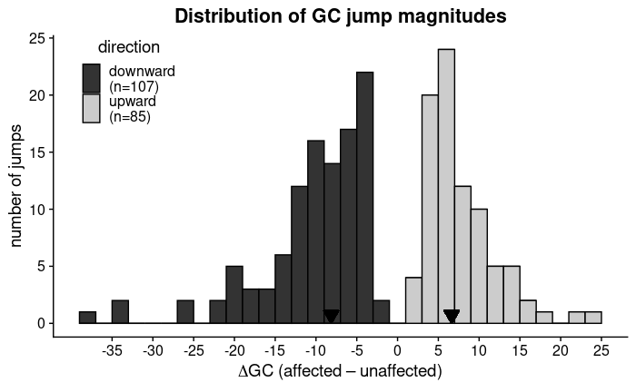

```r
deltaGC_hist
```

```r
print("medians")
```

```
[1] "medians"
```

```r
median(downward_GCjumps_stats$`delta_GC`, na.rm = T)
```

```
[1] -8.14
```

```r
median(upward_GCjumps_stats$`delta_GC`, na.rm = T)
```

```
[1] 6.64
```

```r
print("quartiles")
```

```
[1] "quartiles"
```

```r
quantile(downward_GCjumps_stats$`delta_GC`,0.25)
```

```
   25%
-12.26
```

```r
quantile(upward_GCjumps_stats$`delta_GC`,0.75)
```

```
 75%
9.47
```

```r
print("fraction above 10%")
```

```
[1] "fraction above 10%"
```

```r
length(which(downward_GCjumps_stats$`delta_GC`< (-10)))/nrow(downward_GCjumps_stats)
```

```
[1] 0.411215
```

```r
length(which(upward_GCjumps_stats$`delta_GC` > (10)))/nrow(upward_GCjumps_stats)
```

```
[1] 0.2117647
```

```r
print("fraction above 15%")
```

```
[1] "fraction above 15%"
```

```r
length(which(downward_GCjumps_stats$`delta_GC`< (-15)))/nrow(downward_GCjumps_stats)
```

```
[1] 0.1682243
```

```r
length(which(upward_GCjumps_stats$`delta_GC` > (15)))/nrow(upward_GCjumps_stats)
```

```
[1] 0.05882353
```

#### deltaGC vs GC

```r
bestFit_params <- read.table(paste0(levolution_data_dir, "levolution_best_fit_parameters_summary.txt"))
all_features_df_valid$OLclade <- sapply(rownames(all_features_df_valid), function(y) strsplit(x = y, split = "_")[[1]][1])
Jumps_num <- sapply(OLclades_oi, function(x) length(which(all_features_df_valid$OLclade==x)))
downwardJumps_num <- sapply(OLclades_oi, function(x) length(which(all_features_df_valid[which(all_features_df_valid$OLclade==x),"delta_GC"]<0)))
upwardJumps_num <- sapply(OLclades_oi, function(x) length(which(all_features_df_valid[which(all_features_df_valid$OLclade==x),"delta_GC"]>0)))

deltaGC_vs_GC_df <- as.data.frame(matrix(data = c(bestFit_params[OLclades_oi,"root_state"], Jumps_num, upwardJumps_num,downwardJumps_num), ncol = 4, dimnames = list(OLclades_oi, c("ancestralGC", "jumps_num", "upJumps_num", "downJumps_num"))))

deltaGC_vs_GC_OLclades_plt <- ggplot(data = deltaGC_vs_GC_df, aes(x = ancestralGC, y = upJumps_num/(downJumps_num + upJumps_num))) + geom_point(color=grey(0.5)) + theme_cowplot() + ggtitle("Fraction of upward jumps \n in order-level clades") + theme(plot.title=element_text(hjust=0.5))
deltaGC_vs_GC_OLclades_plt <- deltaGC_vs_GC_OLclades_plt + scale_x_continuous(name="ancestral GC") + scale_y_continuous(name="fraction of upward jumps", limits = c(0,1))
deltaGC_vs_GC_OLclades_plt

all_features_df_valid$endoSymb_status <- factor(all_features_df_valid$endoSymb_status, levels=c(1,0))

deltaGC_vs_GC <- ggplot(data=all_features_df_valid, aes(x = sister_GC, y = delta_GC, color=endoSymb_status)) + geom_point() + theme_cowplot() + theme(legend.position=c(0.02,0.18), plot.title=element_text(hjust=0.5)) + ggtitle("Jump magnitude vs ancestral GC \n for each jump")
deltaGC_vs_GC <- deltaGC_vs_GC + scale_x_continuous(name="ancestral GC (unaffected)") + scale_y_continuous(name = expression(Delta*"GC (affected \u2013 unaffected)")) + scale_color_grey(start = 0, end = 0.5, name = "", labels=c("endosymbionts", "others"))
deltaGC_vs_GC <- deltaGC_vs_GC + geom_smooth(method = "lm", aes(x=sister_GC, y=delta_GC), data=subset(all_features_df_valid, endoSymb_status==0))
deltaGC_vs_GC <- deltaGC_vs_GC + stat_cor(data = subset(all_features_df_valid,endoSymb_status=0), label.y=c(35, 35), label.x=c(50,30)) + stat_regline_equation(data = subset(all_features_df_valid,endoSymb_status=0), label.y=c(30,30), label.x=c(50,30))

deltaGC_vs_GC_all <- deltaGC_vs_GC_OLclades_plt + deltaGC_hist + deltaGC_vs_GC + plot_annotation(tag_levels = "A") + plot_layout(ncol = 3)
# deltaGC_vs_GC_all

ggsave2(filename = "deltaGC_hist_vs_GC_all.png", plot = deltaGC_vs_GC_all, path = jump_common_dir, width = 14, height = 4, units = "in", dpi = 300)
ggsave2(filename = "deltaGC_hist_vs_GC_all.svg", plot = deltaGC_vs_GC_all, path = jump_common_dir, width = 14, height = 4, units = "in", dpi = 300)
```